# School analysis using multilevel models

Daniel Berry and George Rooney

Oct 11 2016

# Introduction

# Loading the data into R

# Load in initial data

```r
subject_data <- read.csv('2015-16_school_subject.csv', stringsAsFactors = FALSE)

accred_data <- read.csv('accreditation_2013_and_after_report.csv', stringsAsFactors = FALSE, skip = 3)

ethnicity_data <- read.csv('school_summaries_ethnicity.csv', stringsAsFactors = FALSE, skip = 4)
ethnicity_data$School.No. <- gsub('\\,','',ethnicity_data$School.No.)
ethnicity_data$School.No.[ethnicity_data$School.No. == 260] <- 231

salary_data <- read.csv('salaries.csv',stringsAsFactors = FALSE)

vote_data <- read.csv('2012_general_results.csv', stringsAsFactors = FALSE)

truancy_data <- read.csv('truancy.csv', stringsAsFactors = FALSE)
truancy_data$X <- NULL
truancy_data$X.1 <- NULL
truancy_data <- truancy_data[1:123,]
```

# Load in 2: more loading

```r
subject_data_high <- subset(subject_data, High.Grade == 12)

ethnicity_data_high <- subset(ethnicity_data, Grade == '12')

vote_data_pres <- subset(vote_data, OfficeTitle == 'President and Vice President' & Party %in% c('Democratic','Republican'))
vote_temp <- melt(vote_data_pres, id.vars = c('LocalityName', 'Party'), measure.vars = 'TOTAL_VOTES')
vote_cast <- dcast(vote_temp, formula = LocalityName + Party ~ variable, fun.aggregate = sum)

vote_cast_2 <- dcast(vote_cast, LocalityName ~ Party, value.var = 'TOTAL_VOTES')
vote_cast_3 <- cbind(vote_cast_2, vote_cast_2[,2:3]/rowSums(vote_cast_2[,2:3]))
names(vote_cast_3) <- c(names(vote_cast_2), paste(names(vote_cast_2[,2:3]), '.pct', sep=''))

salary_data$FY.2014..Actual.Average.Teacher.Salary <- as.numeric(gsub('\\t|\\s|\\,', '', salary_data$FY.2014..Actual.Average.Teacher.Salary))

salary_data$FY.2015..Actual.Average.Teacher.Salary <- as.numeric(gsub('\\t|\\s|\\,', '', salary_data$FY.2015..Actual.Average.Teacher.Salary))

salary_data$FY.2016..Budgeted.Average.Teacher.Salary <- as.numeric(gsub('\\t|\\s|\\,', '', salary_data$FY.2016..Budgeted.Average.Teacher.Salary))
```

# Aggregating the data

# Merge subject dataset with accredidation dataset:

```r
all_data <- merge(x = subject_data_high,
                  y = accred_data,
                  by.x = c('Div.Num','Sch.Num'),
                  by.y = c('Division.Number','School.Number'),
                  suffixes = c('.sdh','.acd'),
                  all = TRUE)
```

# Merge on ethnicity data:

```r
all_data <- merge(x = all_data,
                  y = ethnicity_data_high,
                  by.x = c('Div.Num', 'Sch.Num'),
                  by.y = c('Division.No.', 'School.No.'),
                  suffixes = c('.ad', '.ed'),
                  all = TRUE)
```

# merge on truancy data:

```r
all_data <- merge(x = all_data,
                  y = truancy_data,
                  by.x = c('Div.Num'),
                  by.y = c('Division.No'),
                  suffixes = c('.ad','.t'),
                  all = TRUE)
```

# merge on salary data

```r
all_data <- merge(x = all_data,
                  y = salary_data,
                  by.x = 'Div.Num',
                  by.y = 'Division',
                  suffixes = c('.ad', 'sd'),
                  all = TRUE)
```

# merge on voting data:

```r
all_data$Div.Name <- tolower(str_trim(all_data$Div.Name))
vote_cast_3$LocalityName <- tolower(vote_cast_3$LocalityName)

all_data <- merge(x = all_data,
                  y = vote_cast_3,
                  by.x = 'Div.Name',
                  by.y = 'LocalityName',
                  suffixes = c('.ad','.vc2'),
                  all = TRUE)
```

# compute truancy as a percentage:

```r
## compute truancy percentage:
truancy_data_pct <- ddply(all_data,
                          .(Div.Name),
                          function(df) {
                              mean(df$Truancy.Count) / sum(df$Total..Full.time...Part.time.Students)
                          }
                          )

names(truancy_data_pct) <- c('Div.Name', 'Truancy.pct')

all_data <- merge(x = all_data,
                  y = truancy_data_pct,
                  by = 'Div.Name',
                  all = TRUE)
```

# convert ethnicity to percent of school composition:

```r
races <- c('Native.Hawaiian', 'Asian','White', 'Two.or.more.races', 'Hispanic', 'American.Indian', 'Black')
for (race in races) {
    race_cols <- grep('.pct',grep(race, names(all_data), value = TRUE), value = TRUE)
    all_data[[paste0(race,'.pct')]] <- rowSums(all_data[,race_cols])
}
```

# Examining the modeling dataset

# Selecting the modeling dataset

```r
model_data <- subset(all_data,
                     Subgroup == 'All Students' & Subject == 'Mathematics',
                     select = c('Div.Name',
                                'Div.Num',
                                'School.Name',
                                'Sch.Num',
                                paste0(races,'.pct'),
                                grep('Pass', names(all_data), value = TRUE),
                                'School.Accreditation.Rating',
                                grep('English|Science|Mathematics|History', names(all_data), value = TRUE),
                                'Total..Full.time...Part.time.Students',
                                grep('Salary', names(all_data), value = TRUE),
                                'Democratic.pct',
                                'Truancy.pct'
                                ))
```

# Exploring the data:

# Some plots:

The following are some univariate plots of the predictor variables in the model (using complete cases only)

# Plot of ‘Asian.pct’:

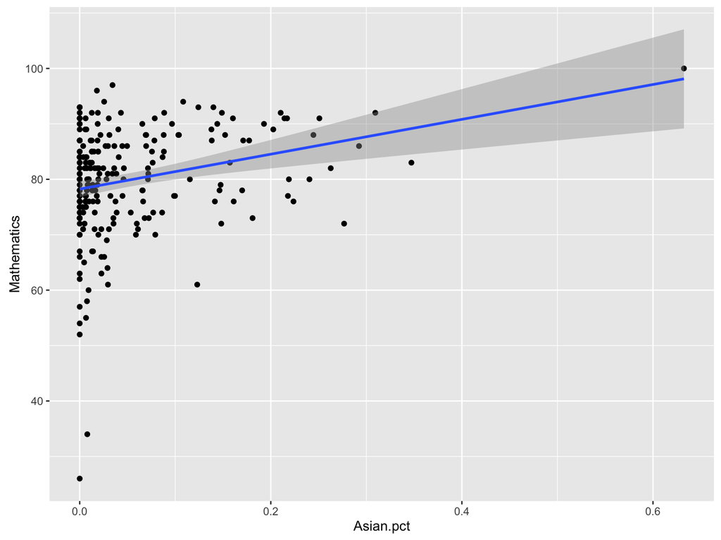

```r
ggplot(model_data, aes_string(x = 'Asian.pct', y = 'Mathematics')) + geom_point() + geom_smooth(method = 'lm')
```

# Plot of ‘Hispanic.pct’:

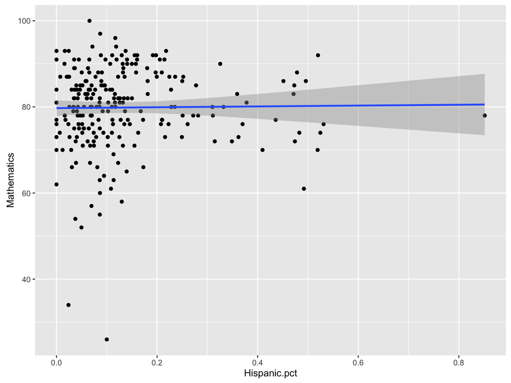

```r
ggplot(model_data, aes_string(x = 'Hispanic.pct', y = 'Mathematics')) + geom_point() + geom_smooth(method = 'lm')
```

# Plot of ‘Black.pct’:

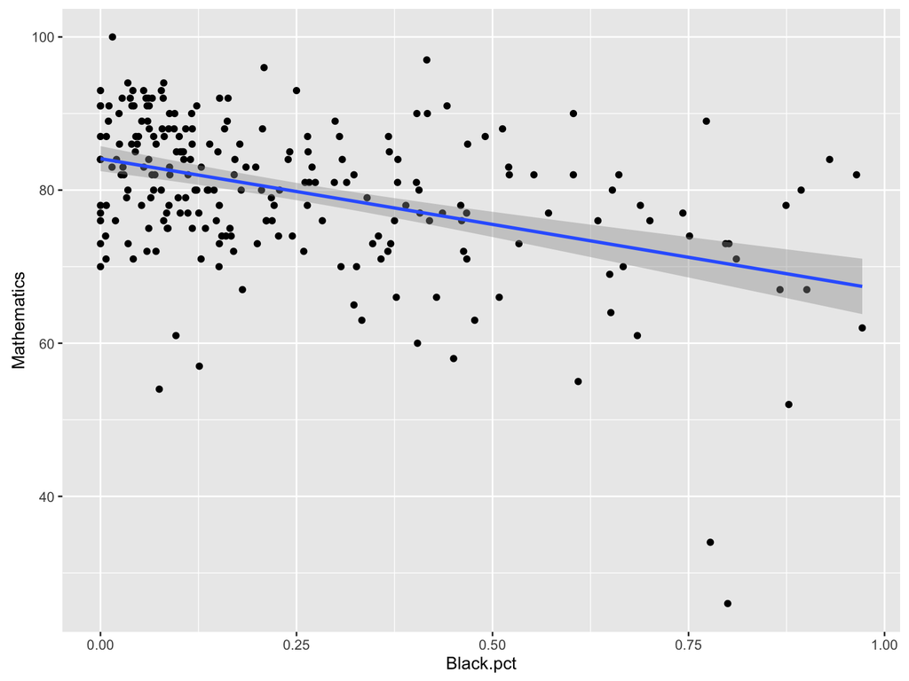

```r
ggplot(model_data, aes_string(x = 'Black.pct', y = 'Mathematics')) + geom_point() + geom_smooth(method = 'lm')
```

# Plot of ‘X2014.2015.Pass.Rate’:

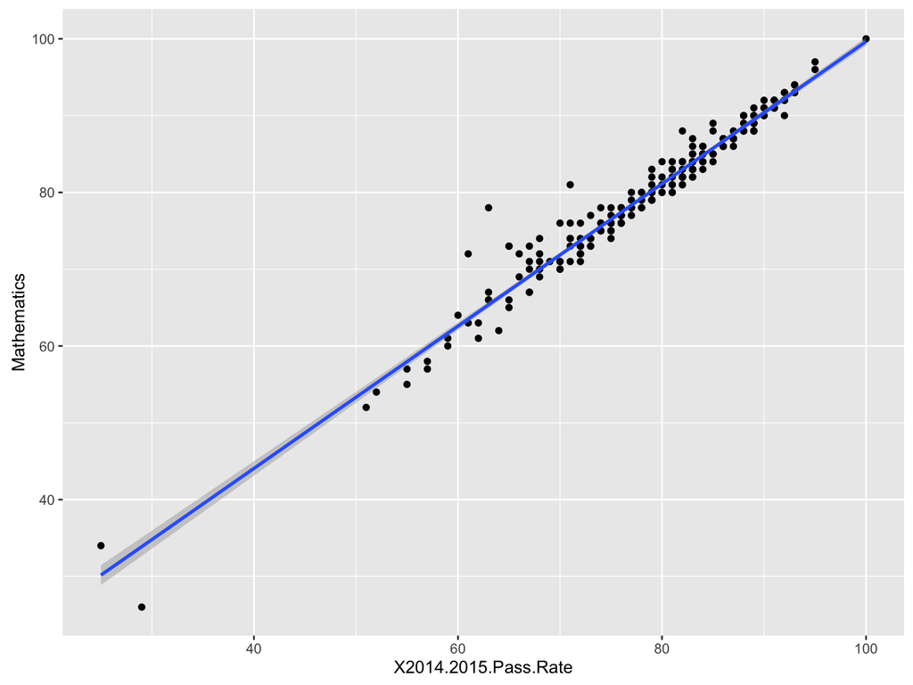

```r
ggplot(model_data, aes_string(x = 'X2014.2015.Pass.Rate', y = 'Mathematics')) + geom_point() + geom_smooth(method = 'lm')
```

# Plot of ‘English’:

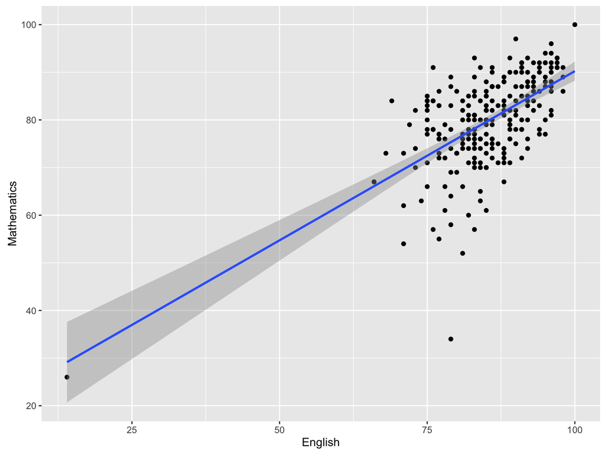

```r
ggplot(model_data, aes_string(x = 'English', y = 'Mathematics')) + geom_point() + geom_smooth(method = 'lm')
```

# Plot of ‘History’:

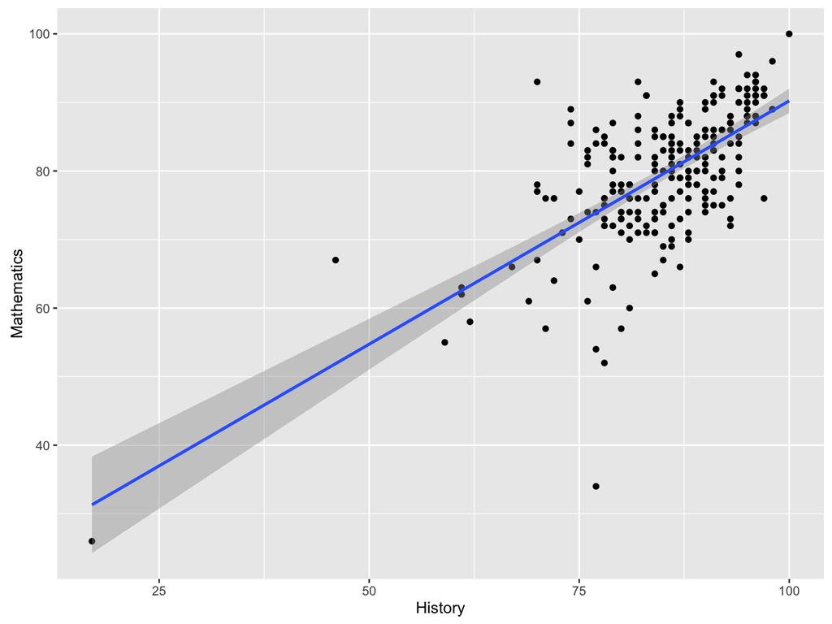

```r
ggplot(model_data, aes_string(x = 'History', y = 'Mathematics')) + geom_point() + geom_smooth(method = 'lm')
```

# Plot of ‘Science’:

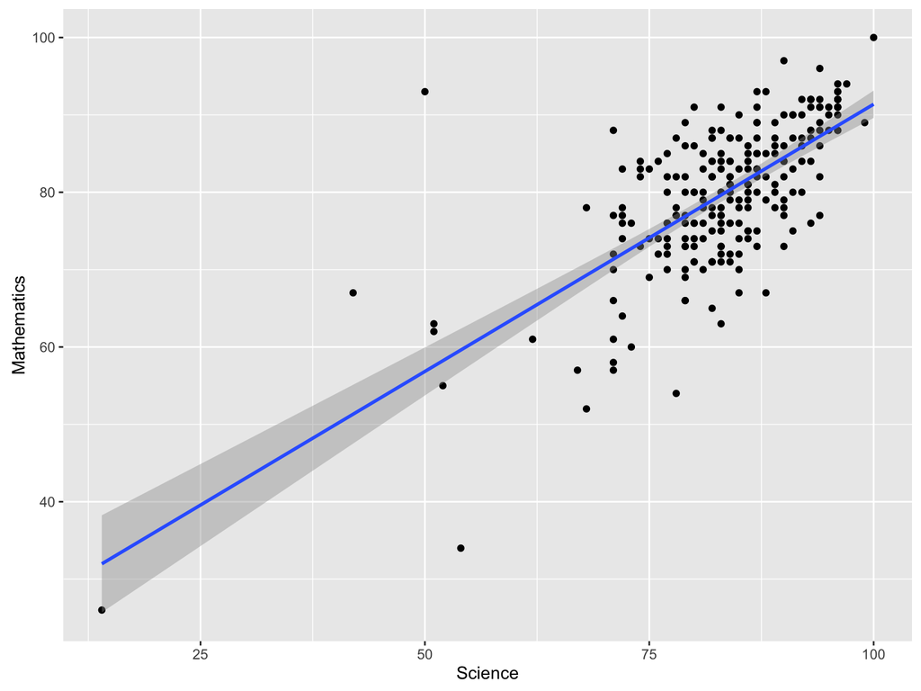

```r
ggplot(model_data, aes_string(x = 'Science', y = 'Mathematics')) + geom_point() + geom_smooth(method = 'lm')
```

# Plot of ‘Total..Full.time Students’:

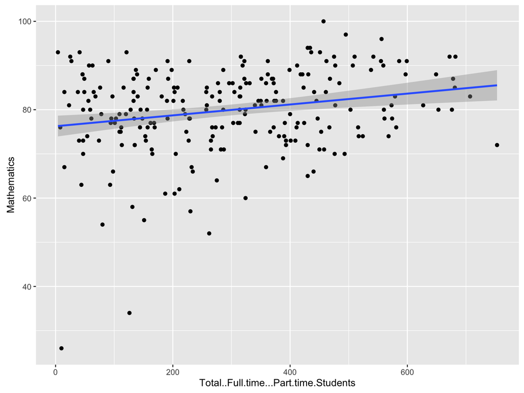

```r
ggplot(model_data, aes_string(x = 'Total..Full.time...Part.time.Students', y = 'Mathematics')) + geom_point() + geom_smooth(method = 'lm')
```

# Plot of ‘FY.2016..Budgeted.Salary’:

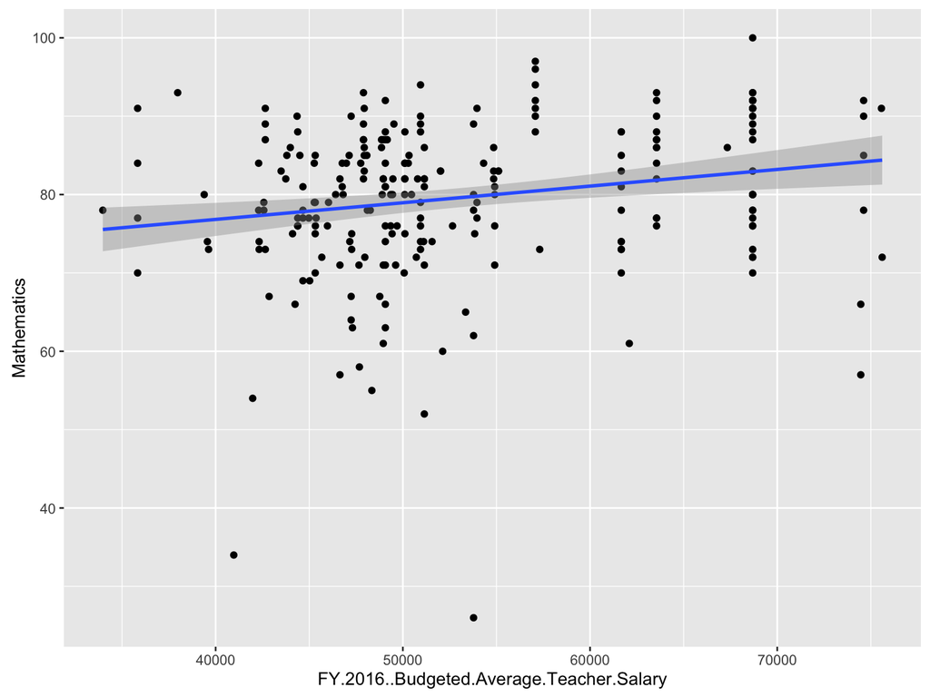

```r
ggplot(model_data, aes_string(x = 'FY.2016..Budgeted.Average.Teacher.Salary', y = 'Mathematics')) + geom_point() + geom_smooth(method = 'lm')
```

# Some collearity:

```r
car::vif(lm(Mathematics ~ . -Div.Name -School.Name -Sch.Num -Div.Num, model_data))
```

```
##                                                  GVIF Df GVIF^(1/(2*Df))
## Native.Hawaiian.pct                          3.768169  1        1.941177
## Asian.pct                                 2141.976561  1       46.281493
## White.pct                                26921.310122  1      164.077147
## Two.or.more.races.pct                        1.839761  1        1.356378
## Hispanic.pct                              6160.307755  1       78.487628
## American.Indian.pct                         22.966925  1        4.792382
## Black.pct                                21372.943131  1      146.194881
## X2013.2014.Pass.Rate                         2.613082  1        1.616503
## X2014.2015.Pass.Rate                         5.909127  1        2.430870
## X2015.2016.Pass.Rate                         4.232380  1        2.057275
## School.Accreditation.Rating                114.153128  4        1.807948
## English                                      5.203640  1        2.281149
## Met.English                                 10.334397  2        1.792963
## Met.Mathematics                             19.628816  2        2.104862
## History                                      5.824579  1        2.413416
## Met.History                                  7.168368  2        1.636270
## Science                                      9.310143  1        3.051253
## Met.Science                                 10.780678  2        1.812014
## Total..Full.time...Part.time.Students        2.470517  1        1.571788
## FY.2014..Actual.Average.Teacher.Salary      25.940009  1        5.093134
## FY.2015..Actual.Average.Teacher.Salary      36.057256  1        6.004769
## FY.2016..Budgeted.Average.Teacher.Salary    23.520251  1        4.849768
## Democratic.pct                               4.136234  1        2.033773
## Truancy.pct                                  1.930603  1        1.389461
```

# Simplify the dataset:

```r
model_data$Native.Hawaiian.pct <- NULL
model_data$American.Indian.pct <- NULL
model_data$Two.or.more.races.pct <- NULL
model_data$White.pct <- NULL

model_data$FY.2014..Actual.Average.Teacher.Salary <- NULL
model_data$FY.2015..Actual.Average.Teacher.Salary <- NULL

model_data$X2013.2014.Pass.Rate <- NULL
model_data$X2015.2016.Pass.Rate <- NULL

model_data$Met.English <- NULL
model_data$Met.History <- NULL
model_data$Met.Science <- NULL

model_data$Met.Mathematics[model_data$Met.Mathematics == 'Not Tested'] <- NA
```

# Which leaves final correlations:

```r
knitr::kable(cor(model_data[,sapply(model_data, is.numeric)]), digits = 2)
```

|  | Div.Num | Asian.pct | Hispanic.pct | Black.pct | X2014.2015.Pass.Rate | English | Mathematics | History | Science | Total..Full.time…Part.time.Students | FY.2016..Budgeted.Average.Teacher.Salary | Democratic.pct | Truancy.pct |
| --- | --- | --- | --- | --- | --- | --- | --- | --- | --- | --- | --- | --- | --- |
| Div.Num | 1 | NA | NA | NA | NA | NA | NA | NA | NA | NA | 0 | NA | NA |
| Asian.pct | NA | 1 | NA | NA | NA | NA | NA | NA | NA | NA | NA | NA | NA |
| Hispanic.pct | NA | NA | 1 | NA | NA | NA | NA | NA | NA | NA | NA | NA | NA |
| Black.pct | NA | NA | NA | 1 | NA | NA | NA | NA | NA | NA | NA | NA | NA |
| X2014.2015.Pass.Rate | NA | NA | NA | NA | 1 | NA | NA | NA | NA | NA | NA | NA | NA |
| English | NA | NA | NA | NA | NA | 1 | NA | NA | NA | NA | NA | NA | NA |
| Mathematics | NA | NA | NA | NA | NA | NA | 1 | NA | NA | NA | NA | NA | NA |
| History | NA | NA | NA | NA | NA | NA | NA | 1 | NA | NA | NA | NA | NA |
| Science | NA | NA | NA | NA | NA | NA | NA | NA | 1 | NA | NA | NA | NA |
| Total..Full.time…Part.time.Students | NA | NA | NA | NA | NA | NA | NA | NA | NA | 1 | NA | NA | NA |
| FY.2016..Budgeted.Average.Teacher.Salary | 0 | NA | NA | NA | NA | NA | NA | NA | NA | NA | 1 | NA | NA |
| Democratic.pct | NA | NA | NA | NA | NA | NA | NA | NA | NA | NA | NA | 1 | NA |
| Truancy.pct | NA | NA | NA | NA | NA | NA | NA | NA | NA | NA | NA | NA | 1 |

# Unfortunately there’s some missing data:

```r
print(paste('Number missing: ',sum(!complete.cases(model_data))))
```

```
## [1] "Number missing:  35"
```

# Missing data analysis

For 2 categorical variables with missing levels: created a new level for missing:

```r
model_data$Met.Mathematics[is.na(model_data$Met.Mathematics)] <- "Missing"
model_data$School.Accreditation.Rating[is.na(model_data$School.Accreditation.Rating)] <- "Missing"
```

For numeric variables we did imputation via `mice`:

```r
mice_hs <- mice(model_data)
model_data_mice <- complete(mice_hs)
```

# Split into train/test:

```r
split <- rbinom(nrow(model_data_mice),1,.8)
model_data_T <- model_data_mice[split*(1:length(split)),]
model_data_V <- model_data_mice[-(split*(1:length(split))),]
```

# First model: complete pooling

# Build the model

Model:
$$Math_i = \beta_0 + \sum_{j=1}^{17} \beta_i\cdot x_{ji}$$

```r
summary(complete_T <- lm(Mathematics ~ ., data = model_data_T[,-c(1:4)]))
```

```
##
## Call:
## lm(formula = Mathematics ~ ., data = model_data_T[, -c(1:4)])
##
## Residuals:
##     Min      1Q  Median      3Q     Max
## -3.4187 -0.9951 -0.1612  0.8309  7.1351
##
## Coefficients: (1 not defined because of singularities)
##                                                                                    Estimate
## (Intercept)                                                                       2.436e+00
## Asian.pct                                                                         3.276e-01
## Hispanic.pct                                                                      5.050e+00
## Black.pct                                                                         8.832e-01
## X2014.2015.Pass.Rate                                                              8.981e-01
## School.Accreditation.RatingConditionally Accredited:  New School                  2.784e+00
## School.Accreditation.RatingFully Accredited                                       2.930e+00
## School.Accreditation.RatingMissing                                                6.290e+00
## School.Accreditation.RatingPartially Accredited: Approaching Benchmark-Pass Rate  4.160e+00
## School.Accreditation.RatingPartially Accredited: Improving School-Pass Rate       5.328e+00
## School.Accreditation.RatingPartially Accredited: Warned School-Pass Rate          2.747e+00
## English                                                                           4.686e-02
## Met.MathematicsNo - Approaching                                                  -3.104e-01
## Met.MathematicsNo - Warned                                                       -1.463e+00
## Met.MathematicsYes                                                                       NA
## History                                                                          -3.606e-02
## Science                                                                           1.745e-02
## Total..Full.time...Part.time.Students                                            -3.234e-03
## FY.2016..Budgeted.Average.Teacher.Salary                                          3.443e-05
## Democratic.pct                                                                   -5.355e-01
## Truancy.pct                                                                       5.215e+00
##                                                                                  Std. Error
## (Intercept)                                                                       2.754e+00
## Asian.pct                                                                         2.062e+00
## Hispanic.pct                                                                      1.375e+00
## Black.pct                                                                         8.978e-01
## X2014.2015.Pass.Rate                                                              2.114e-02
## School.Accreditation.RatingConditionally Accredited:  New School                  1.908e+00
## School.Accreditation.RatingFully Accredited                                       1.518e+00
## School.Accreditation.RatingMissing                                                1.812e+00
```

[output cut: 70 more lines]

```
## Met.MathematicsNo - Approaching
## Met.MathematicsNo - Warned
## Met.MathematicsYes
## History
## Science
## Total..Full.time...Part.time.Students                                            ***
## FY.2016..Budgeted.Average.Teacher.Salary
## Democratic.pct
## Truancy.pct
## ---
## Signif. codes:  0 '***' 0.001 '**' 0.01 '*' 0.05 '.' 0.1 ' ' 1
##
## Residual standard error: 1.604 on 175 degrees of freedom
## Multiple R-squared:  0.9662, Adjusted R-squared:  0.9625
## F-statistic: 263.2 on 19 and 175 DF,  p-value: < 2.2e-16
```

# Examine coefficients:

Table continues below

|  | Estimate | Std. Error | t value |
| --- | --- | --- | --- |
| **Asian.pct** | 0.3276 | 2.062 | 0.1589 |
| **Hispanic.pct** | 5.05 | 1.375 | 3.672 |
| **Black.pct** | 0.8832 | 0.8978 | 0.9837 |
| **X2014.2015.Pass.Rate** | 0.8981 | 0.02114 | 42.49 |
| **School.Accreditation.RatingConditionally Accredited: New School** | 2.784 | 1.908 | 1.459 |
| **School.Accreditation.RatingFully Accredited** | 2.93 | 1.518 | 1.93 |
| **School.Accreditation.RatingMissing** | 6.29 | 1.812 | 3.471 |
| **School.Accreditation.RatingPartially Accredited: Approaching Benchmark-Pass Rate** | 4.16 | 1.727 | 2.409 |
| **School.Accreditation.RatingPartially Accredited: Improving School-Pass Rate** | 5.328 | 1.727 | 3.085 |
| **School.Accreditation.RatingPartially Accredited: Warned School-Pass Rate** | 2.747 | 1.329 | 2.068 |
| **English** | 0.04686 | 0.03226 | 1.453 |
| **Met.MathematicsNo - Approaching** | -0.3104 | 1.856 | -0.1673 |
| **Met.MathematicsNo - Warned** | -1.463 | 1.051 | -1.393 |
| **History** | -0.03606 | 0.02866 | -1.258 |
| **Science** | 0.01745 | 0.03185 | 0.5479 |
| **Total..Full.time…Part.time.Students** | -0.003235 | 0.0009211 | -3.512 |
| **FY.2016..Budgeted.Average.Teacher.Salary** | 3.443e-05 | 2.435e-05 | 1.414 |
| **Democratic.pct** | -0.5355 | 1.591 | -0.3367 |
| **Truancy.pct** | 5.215 | 4.063 | 1.284 |
| **(Intercept)** | 2.436 | 2.754 | 0.8844 |

|  | Pr(>\|t\|) |
| --- | --- |
| **Asian.pct** | 0.8739 |
| **Hispanic.pct** | 0.0003195 |
| **Black.pct** | 0.3266 |
| **X2014.2015.Pass.Rate** | 3.935e-94 |
| **School.Accreditation.RatingConditionally Accredited: New School** | 0.1462 |
| **School.Accreditation.RatingFully Accredited** | 0.05519 |
| **School.Accreditation.RatingMissing** | 0.0006523 |
| **School.Accreditation.RatingPartially Accredited: Approaching Benchmark-Pass Rate** | 0.01702 |
| **School.Accreditation.RatingPartially Accredited: Improving School-Pass Rate** | 0.002365 |
| **School.Accreditation.RatingPartially Accredited: Warned School-Pass Rate** | 0.04015 |
| **English** | 0.1481 |
| **Met.MathematicsNo - Approaching** | 0.8673 |
| **Met.MathematicsNo - Warned** | 0.1655 |
| **History** | 0.21 |
| **Science** | 0.5845 |
| **Total..Full.time…Part.time.Students** | 0.0005668 |
| **FY.2016..Budgeted.Average.Teacher.Salary** | 0.1591 |
| **Democratic.pct** | 0.7368 |
| **Truancy.pct** | 0.201 |
| **(Intercept)** | 0.3777 |

Fitting linear model: Mathematics ~ .

| Observations | Residual Std. Error | $R^2$ | Adjusted $R^2$ |
| --- | --- | --- | --- |
| 195 | 1.604 | 0.9662 | 0.9625 |

# Predict on new data:

```r
cpooling_pred <- predict.lm(complete_T, newdata = model_data_V[,-c(1:4)])
(cp_mse <- sum((model_data_V$Mathematics-cpooling_pred)^2))
```

```
## [1] 187.8135
```

# Predicted vs fitted:

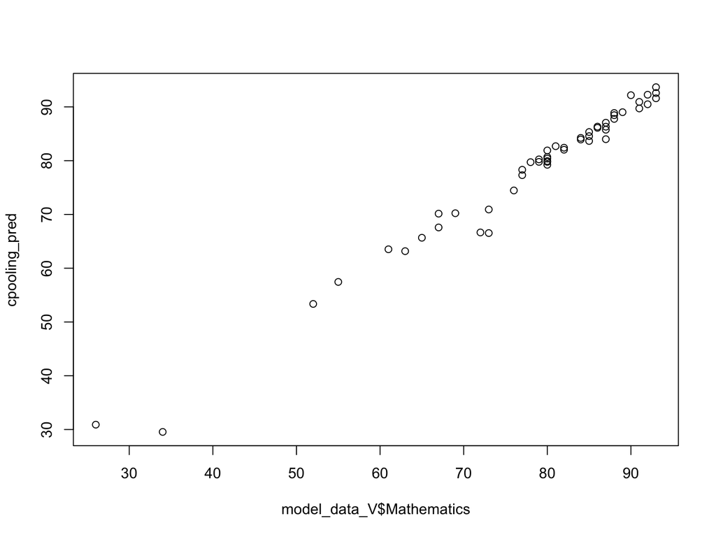

```r
plot(model_data_V$Mathematics, cpooling_pred)
```

# Predicted vs residual

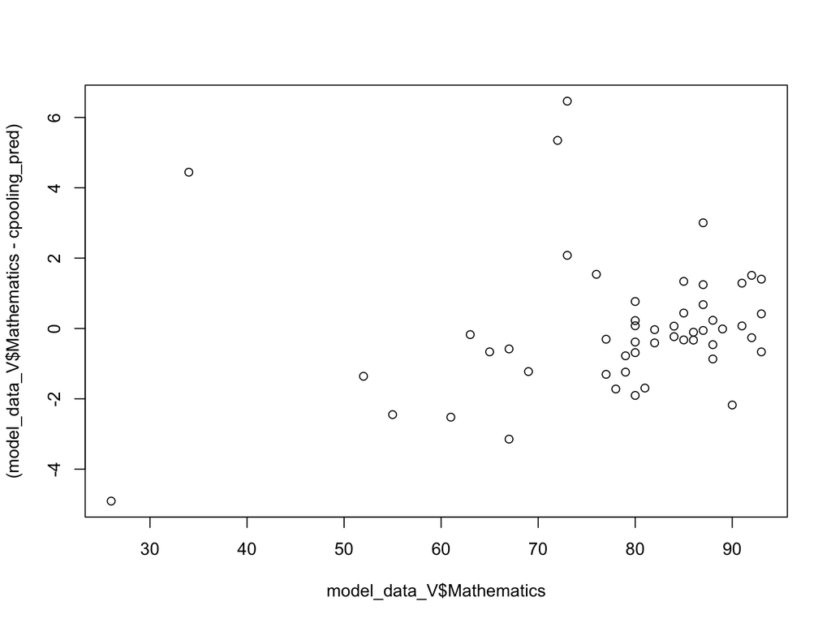

```r
plot(model_data_V$Mathematics, (model_data_V$Mathematics-cpooling_pred))
```

# No pooling model

# Issues:

Due to the fact that there are many districts with only one observation in them, we can’t just simply fit an no pooling model, too many coefficients. However, we should be able to place priors on the coefficients and do a bayesian hierarchical model. So far we’ve only got this working for random slopes for 1 covariate, not sure why we can’t do three.

# Fit the model

```r
no_pooling_2_T <- blmer(Mathematics ~ Asian.pct +
                        Hispanic.pct +
                        Black.pct +
                        X2014.2015.Pass.Rate +
                        School.Accreditation.Rating +
                        English +
                        Met.Mathematics +
                        History +
                        Science +
                        Total..Full.time...Part.time.Students +
                        FY.2016..Budgeted.Average.Teacher.Salary +
                        (1 + FY.2016..Budgeted.Average.Teacher.Salary | Div.Num),
                      model_data_T,
                      cov.prior = wishart)
```

```
## fixed-effect model matrix is rank deficient so dropping 1 column / coefficient
```

# Predict on new data

```r
npooling_pred <- predict(no_pooling_2_T, newdata = model_data_V, allow.new.levels=T)
(np_mse <- sum((model_data_V$Mathematics-npooling_pred)^2))
```

```
## [1] 246.2044
```